# 2 va

Fábio Alves de Freitas

23/10/2020

# Questões

## VADeaths

Visualize o dataset VADeaths (já incluído no R) e crie um gráfico de barras empilhadas desses dados, de modo que as barras estejam agrupadas (lado a lado) para cada categoria. Também defina uma cor diferente para cada grupo das categorias. Por fim, adicione título, legenda e nomes nos eixos. Abaixo submeta o link do RPubs com o resultado dessa questão. Ela deve ficar dentro de uma aba chamada de “VADeaths”

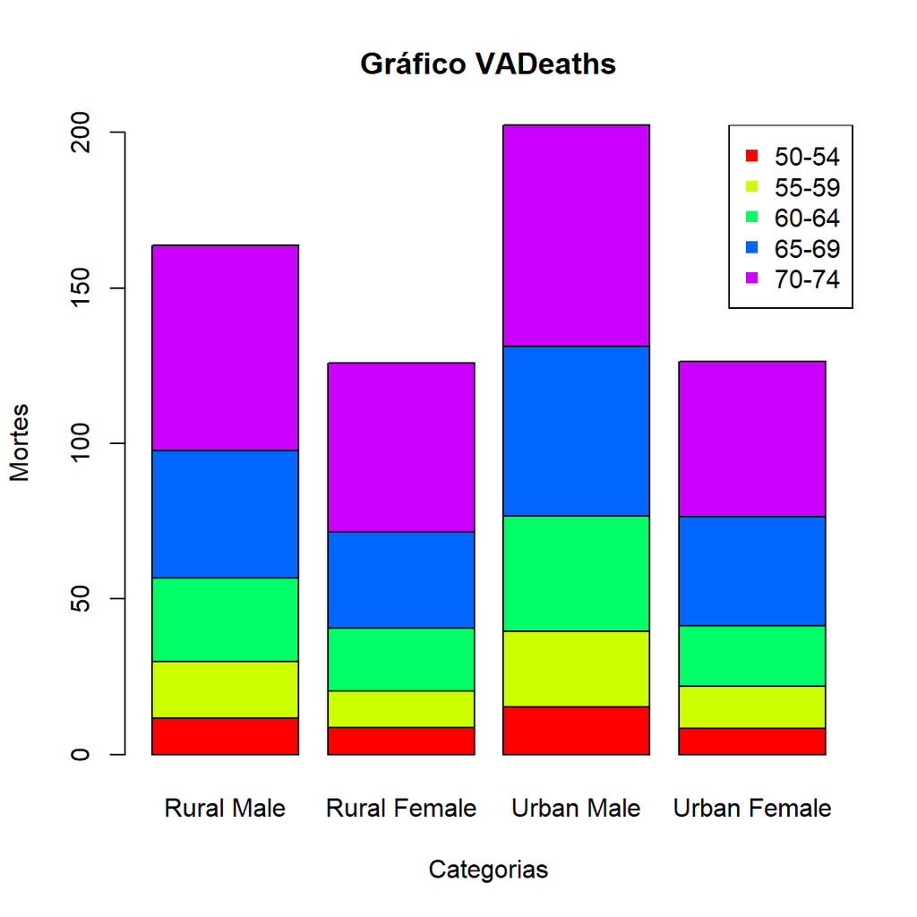

```r
colors <- c(rainbow(5))
categorias <- c("Rural Male", "Rural Female", "Urban Male", "Urban Female")
faixaEtaria <- c("50-54","55-59","60-64","65-69","70-74")
barplot(VADeaths, main = "Gráfico VADeaths", names.arg = categorias,
        xlab = "Categorias", ylab = "Mortes", col = colors)
legend("topright", pch = c(15,15,15,15,15), col = colors, legend = faixaEtaria)
```

## ClassificaçãoDoença

Uma doença pode ser classificada em três estágios (leve, moderado e severo). Foram examinados 20 pacientes e obtidos os dados: moderado, leve, leve, severo, leve, moderado, moderado, moderado, leve, leve, severo,leve, moderado, moderado, leve, severo, moderado, moderado, moderado,leve. Com base nestes dados crie um gráfico de piza. Inclua a porcentagem de cada fatia, as cores das fatias e o nome do gráfico. Adicionalmente, use o comando legend() para incluir a legenda do gráfico. Abaixo submeta o link do RPubs com o resultado dessa questão. Ela deve ficar dentro de uma aba chamada de “ClassificaçãoDoença”. Note que apenas um link do RPubs é necessário. Basta repetir o link abaixo se você já tiver submetido para outras questões.

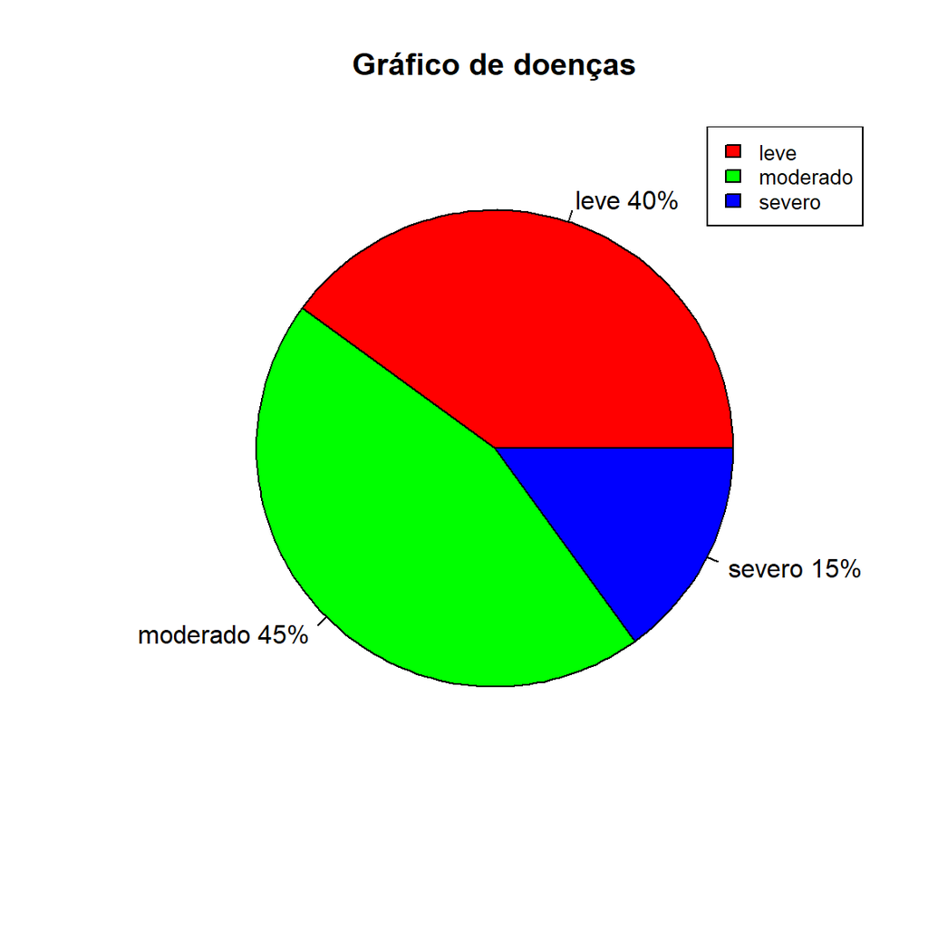

```r
dados <- c(8, 9, 3)
rotulos <- c("leve", "moderado", "severo")
pct <- round(dados/sum(dados)*100)
lbls <- paste(rotulos, pct)
lbls <- paste(lbls, "%", sep="")
pie(dados, labels = lbls, main = "Gráfico de doenças", col = rainbow(3))
legend("topright", legend = rotulos, cex = 0.8, fill = rainbow(length(dados)))
```

## Twitters

Crie uma nuvem de palavra a partir dos twitters sobre a hashtag “#racismo”. Também faça uma análise de sentimentos com relação a esses twitters coletados. Abaixo submeta o link do R Markdown com o resultado dessa questão. Ela deve ficar dentro de uma aba chamada de “Twitters”. Note que apenas um link do RPubs é necessário. Basta repetir o link abaixo se você já tiver submetido para outras questões.

```r
setup_twitter_oauth(
  consumer_key,
  consumer_secret,
  access_token,
  access_secret
)
```

```
## [1] "Using direct authentication"
```

```r
tweets <- searchTwitter("#racismo", n=500, lang="pt")
tweets <- twListToDF(tweets)
tweets_t <- paste(tweets$text, collapse= " ")

VS <- VectorSource(tweets_t)
corpus <- Corpus(VS)
inspect(corpus)
```

```
## <<SimpleCorpus>>
## Metadata:  corpus specific: 1, document level (indexed): 0
## Content:  documents: 1
##
## [1] RT @yosefbless: Delegada carioca, candidata a prefeitura de Recife, mostra o pior da direita do ódio com discurso eugenista. Entenda pq ess… RT @yosefbless: Delegada carioca, candidata a prefeitura de Recife, mostra o pior da direita do ódio com discurso eugenista. Entenda pq ess… RT @yosefbl…
```

```r
#limpeza
corpus <- tm_map(corpus, tolower)
corpus <- tm_map(corpus, removePunctuation)
corpus <- tm_map(corpus, stripWhitespace)
corpus <- tm_map(corpus, removeWords, stopwords('portuguese'))
#remover urls
removeURL <- function(x) gsub("http[^[:space:]]*", "", x)
corpus <- tm_map(corpus, removeURL)
#remove tudo o que nao sejam letras em pt-br e espaço
removeNumPunct <- function(x) gsub("[^[:alpha:][:space:]]*", "", x)
corpus <- tm_map(corpus, removeNumPunct)
```

[figure not shown]

```r
#gera matriz com frequencia palavras
tdm <- as.matrix(TermDocumentMatrix(corpus))

#ordena por frequencia
fre <- sort(rowSums(tdm), decreasing = T)

wordcloud(
  corpus,
  min.freq = 3,
  max.words=Inf,
  random.order=F,
  rot.per=0.15,
  colors=brewer.pal(8, "Dark2"),
  scale=c(8,.2)
)
```

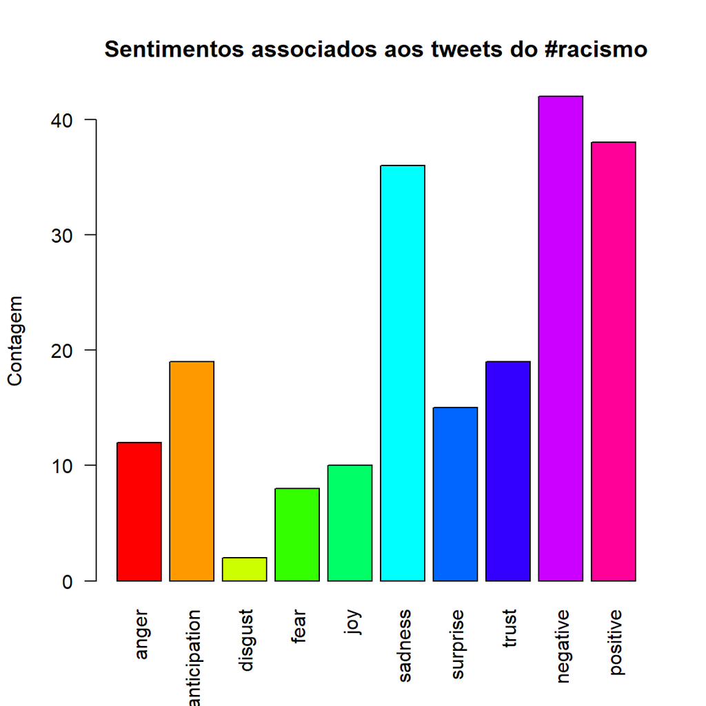

```r
barplot(colSums(sentiments), las=2, col = rainbow(10),
        ylab="Contagem", main = "Sentimentos associados aos tweets do #racismo")
```

## Teorema

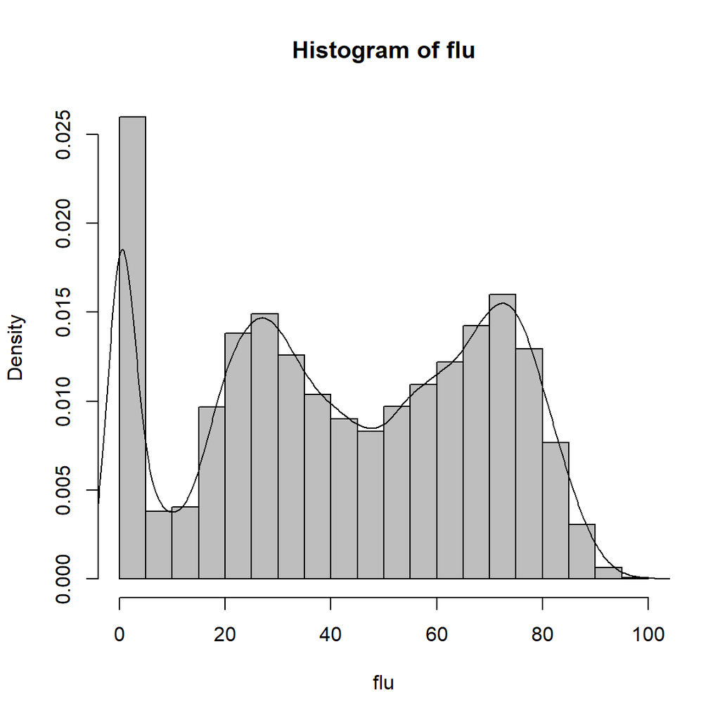

```r
flu <- read.csv("flu.csv", header = T)
flu <- flu$age
hist(flu, col = 'grey', probability = T)
densityFlu <- density(flu)
lines(densityFlu)
```

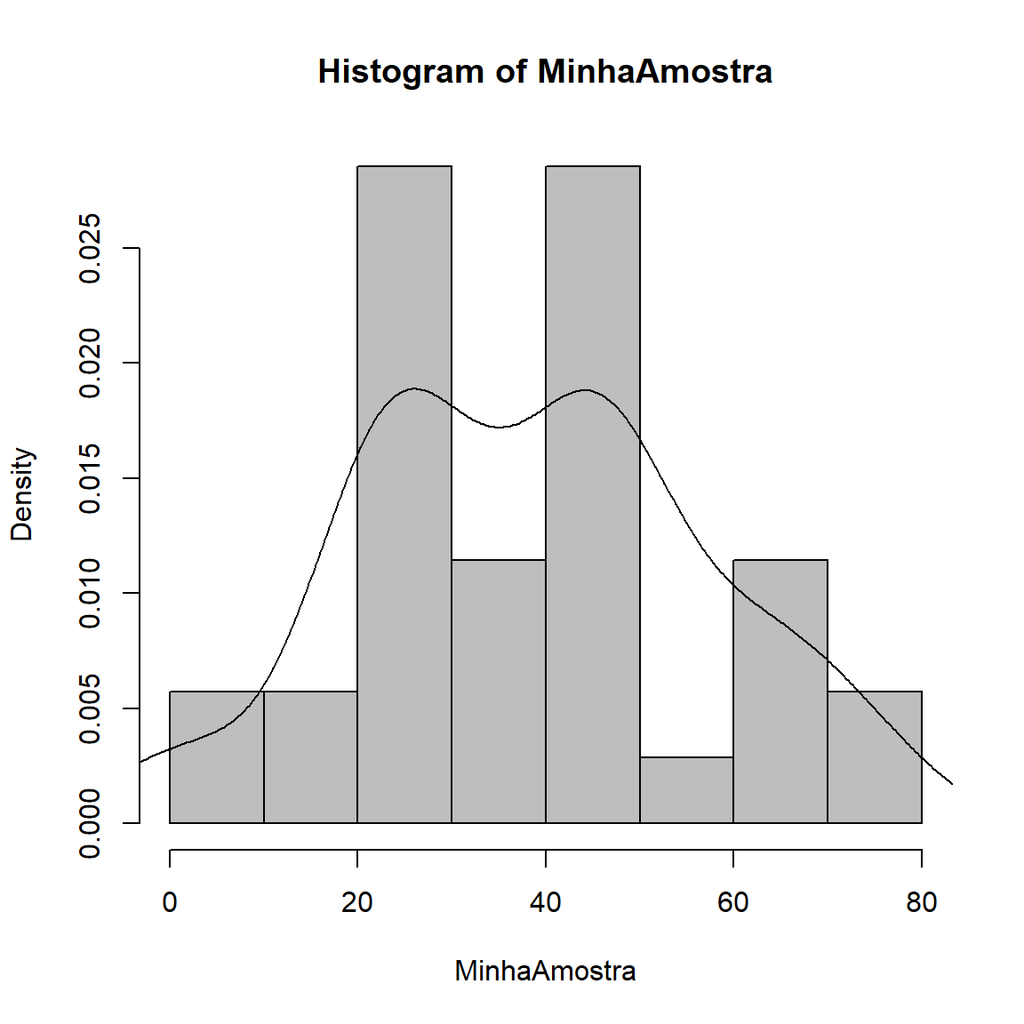

```r
n <- 200
TamMedia <- 35
xbar <- rep(NA, n)
for(i in 1:n) {
  MinhaAmostra <- sample(flu, size = TamMedia)
  xbar[i] <- mean(MinhaAmostra)
}
hist(MinhaAmostra, col = 'grey', probability = T)
densityXbar <- density(MinhaAmostra)
lines(densityXbar)
```